# Results v2

## Model results

The figures show the model results depending on the overall dataset used for model training and testing (x axis) and the subdataset used for training (headline in plots). All plots together give an impression on how sensitive the model is regarding the available dataset for model training and testing (i.e. which years and exploratories).

For example, the first plot on the left shows the results if data from (i) 2017 and 2018, (ii) 2017, 2018, 2019, (iii) 2017 and 2019, and (iv) 2018 and 2019 was available for model training and testing. The performance is computed based on a left out dataset encompassing all data from 2017.

Hence, the very left entry on the x axis (ALL_2017_2018) indicates the model performance if the model is trained on data from 2018 and tested on data from 2017. The very right entry on the x axis (ALL_2018_2019) does not show any model performance because if only data from 2018 and 2019 is available, data from 2017 cannot be left out.

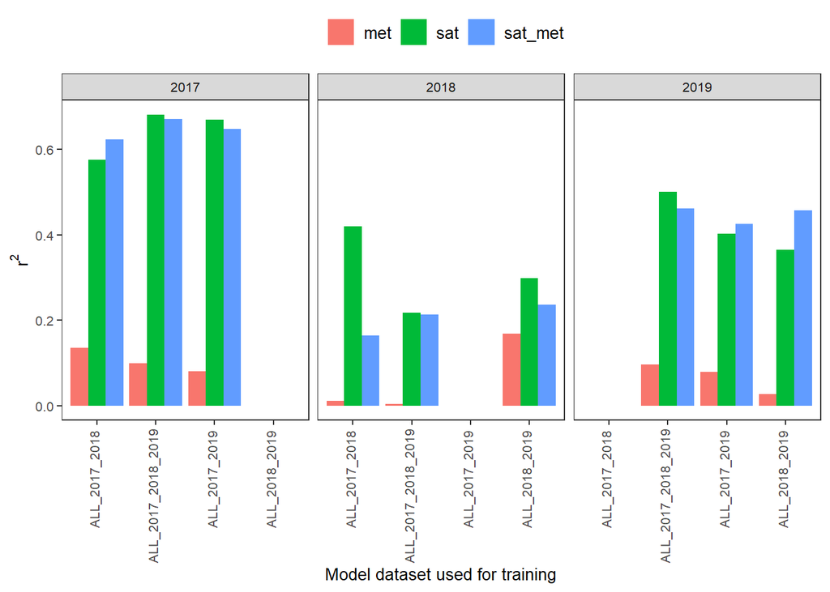

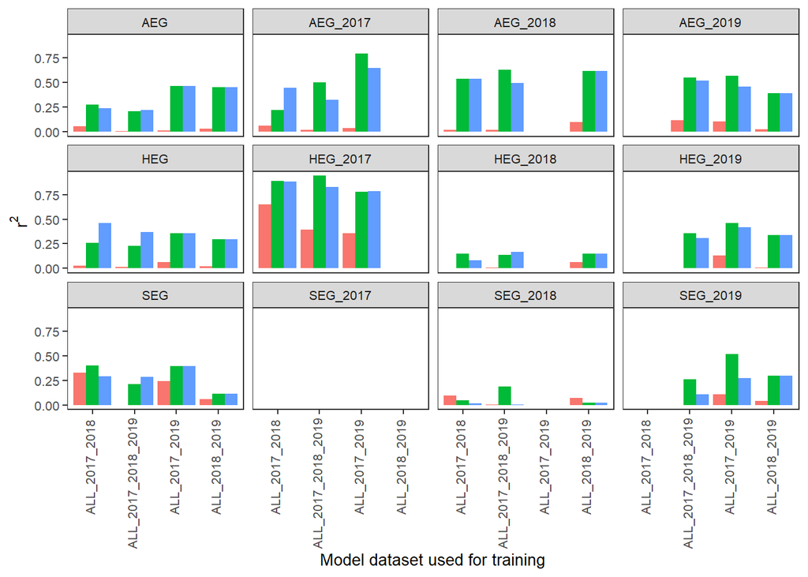

## Predictor importance

Mean predictor importance averaged over all model runs if importance is larger 0.

```
##     Predictor_Group                 Predictors Importance
## 13              sat          DSWI_mean_gam_auc   64.00000
## 17              sat     DSWI_mean_gam_q025_val   60.50000
## 56              sat     NDII_mean_tp_max_value   60.00000
## 18              sat     DSWI_mean_gam_q075_val   51.54762
## 8               sat        B12_sd_tp_max_value   50.00000
## 15              sat     DSWI_mean_gam_mean_val   50.00000
## 23              sat     DSWI_mean_tp_max_value   50.00000
## 51              sat     NDII_mean_gam_q075_val   50.00000
## 69              sat     NDVI_mean_gam_q025_val   50.00000
## 79              sat       NDVI_sd_gam_q025_val   50.00000
## 122             sat          REIP_sd_tp_max_jd   50.00000
## 132             sat    SATVI_mean_gam_mean_val   50.00000
## 134             sat   SATVI_mean_tp_1st_max_jd   50.00000
## 152             sat      SATVI_sd_tp_max_value   50.00000
```

[output cut: 22 more lines]

```
##     Predictor_Group                   Predictors Importance
## 22          sat_met      DSWI_mean_tp_1st_max_jd   55.50000
## 80          sat_met         NDVI_sd_gam_q025_val   52.50000
## 9           sat_met          B12_sd_tp_max_value   50.00000
## 16          sat_met       DSWI_mean_gam_mean_val   50.00000
## 19          sat_met       DSWI_mean_gam_q075_val   50.00000
## 24          sat_met       DSWI_mean_tp_max_value   50.00000
## 26          sat_met            DSWI_mean_tp_pits   50.00000
## 52          sat_met       NDII_mean_gam_q075_val   50.00000
## 70          sat_met       NDVI_mean_gam_q025_val   50.00000
## 123         sat_met            REIP_sd_tp_max_jd   50.00000
## 133         sat_met      SATVI_mean_gam_mean_val   50.00000
## 135         sat_met     SATVI_mean_tp_1st_max_jd   50.00000
## 153         sat_met        SATVI_sd_tp_max_value   50.00000
## 57          sat_met       NDII_mean_tp_max_value   48.78571
```

[output cut: 20 more lines]

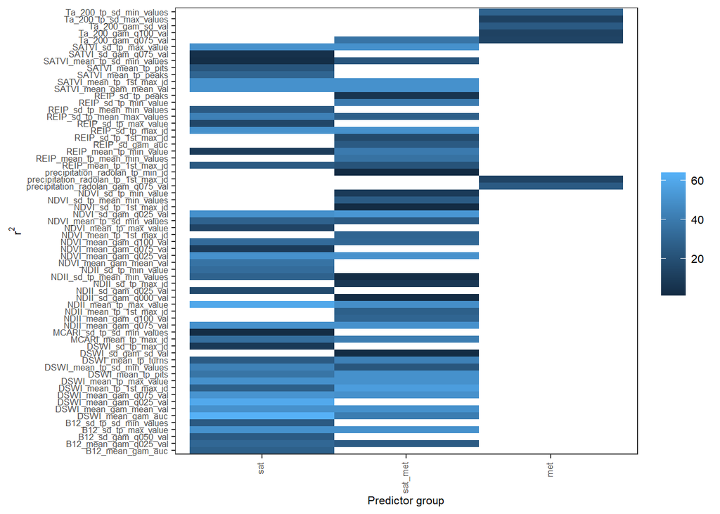